# CA2

```python
import cv2 as cv
import numpy as np
import random
import string
import os
import csv
import math
from PIL import Image, ImageDraw, ImageFont, ImageOps
import matplotlib.pyplot as plt
from skimage.metrics import structural_similarity as ssim
from functools import cmp_to_key
```

## PART 1 - Data Generation

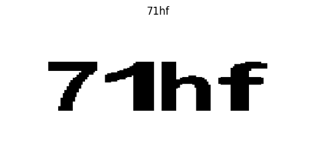

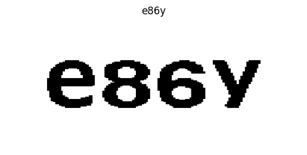

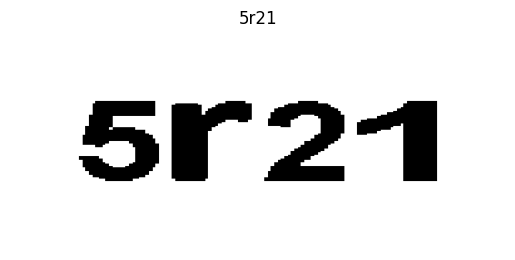

```python
dataset = []

length = 4
chars = string.digits + string.ascii_lowercase
number = 20
random.seed(42)

margin = 50

for i in range(0, number):
    random_string = ''.join(random.choice(chars) for _ in range(length))

    files = []
    for j in random_string:
        files.append(f'Mapset\\{j}.png')

    images = [Image.open(f).convert("RGB") for f in files]

    space = 10
    widths = [img.width + space for img in images]
    heights = [img.height + space for img in images]
    total_width = sum(widths)
    max_height = max(heights)

    result = Image.new("RGB", (total_width, max_height), "Black")

    x_offset = int(space / 2)
    for img in images:
        result.paste(img, (x_offset, int(space / 2)))
        x_offset = x_offset + img.width + space

    result = ImageOps.expand(result, border=margin, fill="black")
    result = ImageOps.invert(result)

    dataset.append((random_string, result.copy()))

num_for_report = 3
for img_name, img in dataset[:num_for_report]:
    plt.imshow(img)
    plt.title(img_name)
    plt.axis("off")
    plt.show()
```

Because the font used in the map set was not specified in the exercise statement, it was difficult to recognize the similarity between the two items without using complex learning-based methods, especially with the font variation, I tried many different approaches to detect it but it wasn't successful. Therefore, I used the map set to construct the sentence, but I attempted to make it look like a normal expression by adjusting the spacing and margins.

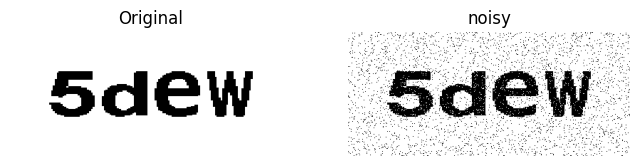

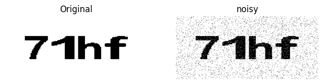

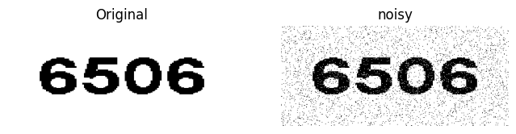

```python
# 3
def salt_pepper_noise(image, prob=0.02):
    noisy = image.copy()

    rnd = np.random.rand(*image.shape[:2])

    salt = rnd < prob/2
    pepper = rnd > 1 - prob/2

    noisy[salt] = 255
    noisy[pepper] = 0

    return noisy

dataset_with_noise = []

for img_name, file in dataset:
    img = np.array(file)

    noisy_img = salt_pepper_noise(img, prob = 0.1)

    dataset_with_noise.append((img_name, noisy_img.copy()))

# Report
random.seed(42)

names = [img_name for img_name, img in dataset]
selected = random.sample(names, 3)

for name in selected:
    fig, axes = plt.subplots(1, 2, figsize=(8, 12))
    img1 = dict(dataset)[name]
    img2 = dict(dataset_with_noise)[name]

    axes[0].imshow(img1)
    axes[0].axis("off")
    axes[0].set_title("Original")
    axes[1].imshow(img2)
    axes[1].axis("off")
    axes[1].set_title("noisy")

    plt.show()
```

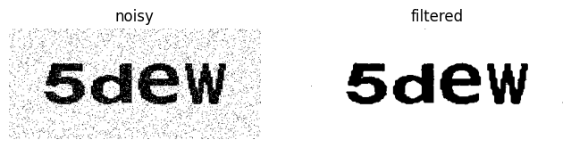

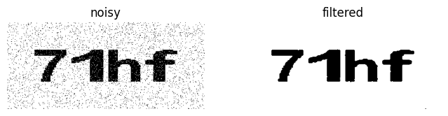

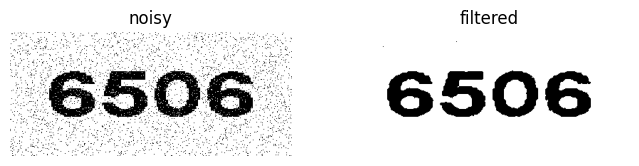

```python
# 4
dataset_after_filtering = []

for img_name, file in dataset_with_noise:
    img = np.array(file)

    filtered_img = cv.medianBlur(img, 3)

    dataset_after_filtering.append((img_name, filtered_img.copy()))

# Report
random.seed(42)

names = [img_name for img_name, img in dataset_with_noise]
selected = random.sample(names, 3)

for name in selected:
    fig, axes = plt.subplots(1, 2, figsize=(8, 12))
    img1 = dict(dataset_with_noise)[name]
    img2 = dict(dataset_after_filtering)[name]

    axes[0].imshow(img1)
    axes[0].axis("off")
    axes[0].set_title("noisy")
    axes[1].imshow(img2)
    axes[1].axis("off")
    axes[1].set_title("filtered")

    plt.show()
```

### Part 1 - Question 4

Since our goal is to remove noise from the images, we need to use a **low-pass filter**. In general, there are two main categories of filters that can be used for this purpose: **linear filters** and **non-linear filters**.

In this case, we used a **median filter**, which is a non-linear filter. The reason is that the noise added to the images is **salt-and-pepper noise**. This type of noise appears as random black and white pixels, and the median filter is especially effective at removing it. Unlike linear filters such as the mean filter, the median filter can reduce this noise while preserving edges and important image details much better.

As can be seen from the results, the filtered images achieved good quality and the noise was removed effectively.

## PART 2 - Data Preprocessing

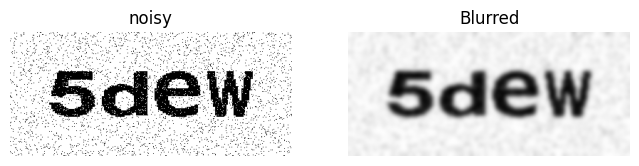

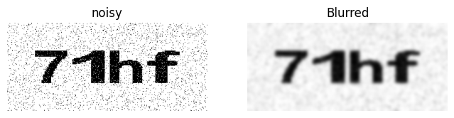

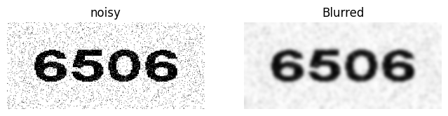

```python
# 1
dataset_after_Blurred = []

for img_name, file in dataset_with_noise:
    img = np.array(file)

    blurred = cv.GaussianBlur(img, (19, 19), 0)

    dataset_after_Blurred.append((img_name, blurred.copy()))

# Report
random.seed(42)

names = [img_name for img_name, img in dataset_with_noise]
selected = random.sample(names, 3)

for name in selected:
    fig, axes = plt.subplots(1, 2, figsize=(8, 12))
    img1 = dict(dataset_with_noise)[name]
    img2 = dict(dataset_after_Blurred)[name]

    axes[0].imshow(img1)
    axes[0].axis("off")
    axes[0].set_title("noisy")
    axes[1].imshow(img2)
    axes[1].axis("off")
    axes[1].set_title("Blurred")

    plt.show()
```

### Part 2 – Question 1

It is known that filters that blur an image can also help reduce noise. The reason for this is that most types of image noise appear as **high‑frequency variations** in pixel intensity. Blurring filters act as **low‑pass filters**, meaning they smooth the image by reducing these high-frequency components. As a result, sudden intensity changes caused by noise are suppressed.

In this part, we applied a **Gaussian filter** . The Gaussian filter replaces each pixel with a weighted average of its neighboring pixels, where pixels closer to the center have greater influence. This smoothing process reduces random noise while keeping the overall structure of the image.

For better noise reduction, a larger kernel size such as **(7×7)** or **(9×9)** can be used. Increasing the kernel size increases the smoothing effect and helps remove more noise, although it may also slightly blur important image details.

Example implementation:

```
blurred = cv.GaussianBlur(img, (7,7), 5)
```

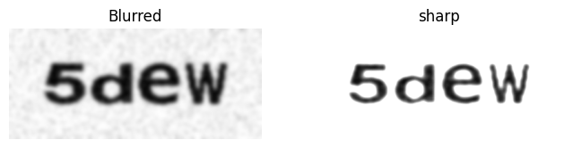

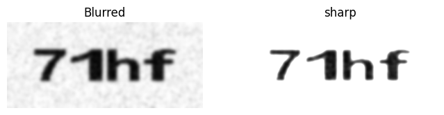

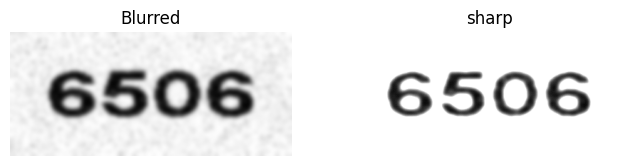

```python
# 2
dataset_after_sharping = []

kernel = np.array([[0, -1, 0],
[-1, 6, -1],
[0, -1, 0]])

for img_name, file in dataset_after_Blurred:
    img = np.array(file)

    sharpened_img = cv.filter2D(img, -1, kernel)

    dataset_after_sharping.append((img_name, sharpened_img.copy()))

# Report
random.seed(42)

names = [img_name for img_name, img in dataset_after_Blurred]
selected = random.sample(names, 3)

for name in selected:
    fig, axes = plt.subplots(1, 2, figsize=(8, 12))
    img1 = dict(dataset_after_Blurred)[name]
    img2 = dict(dataset_after_sharping)[name]

    axes[0].imshow(img1)
    axes[0].axis("off")
    axes[0].set_title("Blurred")
    axes[1].imshow(img2)
    axes[1].axis("off")
    axes[1].set_title("sharp")

    plt.show()
```

### Part 2 – Question 2

Two common approaches for improving blurry images are **Sharpening** and **De-blurring**.

**Sharpening** enhances the edges and fine details of an image by increasing the contrast between neighboring pixels. It works by emphasizing high‑frequency components in the image, which correspond to edges and texture. A common implementation is to apply a sharpening kernel or use techniques such as **unsharp masking**. Sharpening does not truly remove blur, but it improves the visual perception of details by strengthening edges.

**De-blurring**, on the other hand, attempts to **recover the original image by reversing the blur process mathematically**. When an image becomes blurred, it is usually the result of a **convolution** between the original image and a blur kernel (also called the **Point Spread Function – PSF**). De‑blurring methods try to estimate this blur kernel and then apply **deconvolution** to reconstruct the original sharp image.

Common causes of blur include:

- **Motion blur** (camera or object movement during exposure)
- **Gaussian blur** (defocus or smoothing filters)
- **Out‑of‑focus blur** caused by lens limitations

Several algorithms are used for de‑blurring, such as:

- **Inverse filtering**
- **Wiener filtering**
- **Blind deconvolution**

However, de‑blurring methods are usually **more complex and sensitive to noise**, because the process of reversing blur may amplify noise and artifacts in the image. In many practical applications, accurate knowledge of the blur kernel is also required, which makes the process more difficult.

In this work, **Sharpening** was selected to reduce the blur in the images. The reason for this choice is that sharpening is **simpler, computationally efficient, and does not require prior knowledge of the blur model**. It improves edge contrast and makes the image visually clearer, which is sufficient for our application.

Example sharpening kernel:

```
kernel = np.array([
[0, -1, 0],
[-1, x, -1],
[0, -1, 0]
])

x > 4 to create sharpening effect
sharpened_img = cv.filter2D(img, -1, kernel)
```

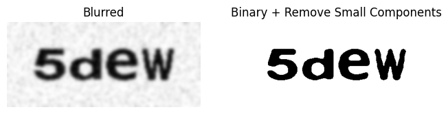

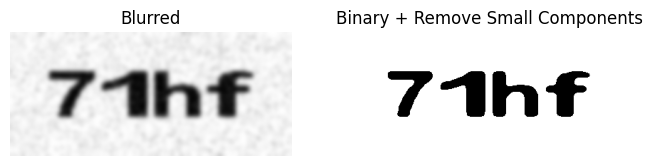

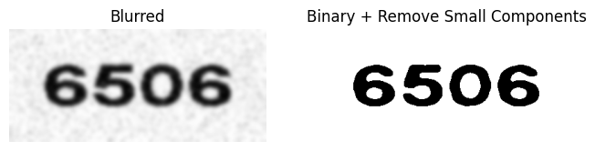

```python
# 3
dataset_after_Binary = []

threshold = 50

for img_name, file in dataset_after_Blurred:
    img = np.array(file)

    gray = cv.cvtColor(img, cv.COLOR_RGB2GRAY)
    _, Binary_img = cv.threshold(gray, 127, 255, cv.THRESH_BINARY)

    num_labels, labels, stats, _ = cv.connectedComponentsWithStats(Binary_img, connectivity=8)

    clean = np.zeros_like(Binary_img)

    for i in range(1, num_labels):
        area = stats[i, cv.CC_STAT_AREA]
        if area >= threshold:
            clean[labels == i] = 255

    dataset_after_Binary.append((img_name, clean.copy()))


# Report
random.seed(42)

names = [img_name for img_name, img in dataset_after_Blurred]
selected = random.sample(names, 3)

for name in selected:
    fig, axes = plt.subplots(1, 2, figsize=(8, 12))

    img1 = dict(dataset_after_Blurred)[name]
    img2 = dict(dataset_after_Binary)[name]

    axes[0].imshow(img1)
    axes[0].axis("off")
    axes[0].set_title("Blurred")

    axes[1].imshow(img2, cmap="gray")
    axes[1].axis("off")
    axes[1].set_title("Binary + Remove Small Components")

    plt.show()
```

### Part 2 – Question 3

Threshold means **a threshold or boundary** between two states. It represents the minimum value that must be exceeded for something to happen.

In this problem, my interpretation is that the **area of a component** can be used as the threshold. In other words, a component must have an area larger than this value to be considered significant.

To find an appropriate threshold value, we usually need to use **trial and error**.

## PART3 - Segmentation

In the previous part(part 2) of the HW2, we obtained the binary image

```
5dew: 4 characters extracted
```

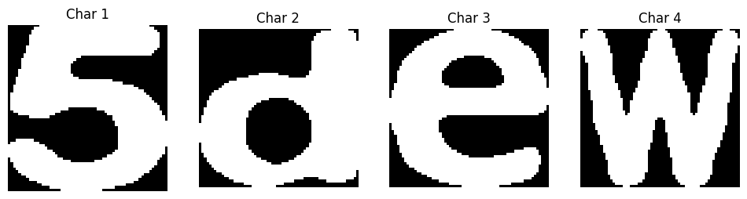

```
71hf: 4 characters extracted
```

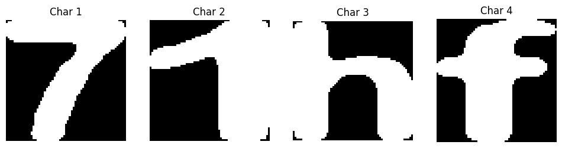

```
65o6: 4 characters extracted
```

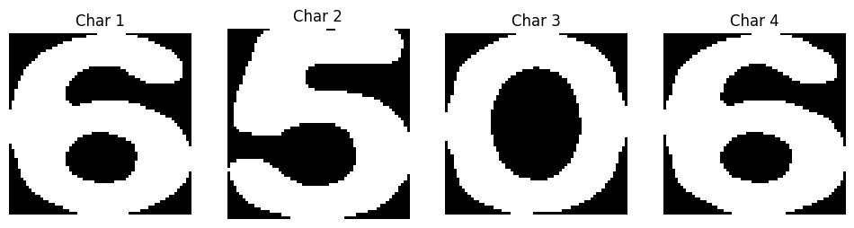

```python
# 1
def component_compare(a, b):
    x1, y1, w1, h1 = a
    x2, y2, w2, h2 = b

    area1 = w1 * h1
    area2 = w2 * h2

    left = max(x1, x2)
    right = min(x1 + w1, x2 + w2)
    overlap = right - left

    if overlap > min(w1, w2) * 0.5: # its i j case
        return area1 - area2

    return x1 - x2


extracted_characters = []
character_counts = []

min_area = threshold

for img_name, binary_img in dataset_after_Binary:

    binary_img = 255 - binary_img # like mapset

    num_labels, labels, stats, _ = cv.connectedComponentsWithStats(binary_img, connectivity=8)

    components = []

    for i in range(1, num_labels):
        area = stats[i, cv.CC_STAT_AREA]

        if area >= min_area:
            x = stats[i, cv.CC_STAT_LEFT]
            y = stats[i, cv.CC_STAT_TOP]
            w = stats[i, cv.CC_STAT_WIDTH]
            h = stats[i, cv.CC_STAT_HEIGHT]

            components.append((x, y, w, h))

    components = sorted(components, key=cmp_to_key(component_compare)) # to keep organized

    chars_in_this_image = []
    prev_cor = [0, 0, 0, 0] # Previous coordinates
    for x, y, w, h in components:

        if abs((x+w + x)/2 - (prev_cor[0]+prev_cor[2] + prev_cor[0])/2) < 10: # have i or j
            char_crop = binary_img[y-prev_cor[3]-5:y+h, x:x+w] # 5 is came from testing
            chars_in_this_image.pop() # delete dot (i j)
        else:
            char_crop = binary_img[y:y+h, x:x+w]
        prev_cor = [x, y, w, h]

        chars_in_this_image.append(char_crop)

    extracted_characters.append((img_name, chars_in_this_image))
    character_counts.append((img_name, len(chars_in_this_image)))

#Report
random.seed(42)
selected = random.sample(extracted_characters, 3)

for img_name, chars in selected:

    print(f"{img_name}: {len(chars)} characters extracted")

    fig, axes = plt.subplots(1, len(chars), figsize=(3*len(chars), 3))

    for i, char_img in enumerate(chars):
        axes[i].imshow(char_img, cmap="gray")
        axes[i].axis("off")
        axes[i].set_title(f"Char {i+1}")

    plt.show()
```

```
5dew: 4 resized characters
```

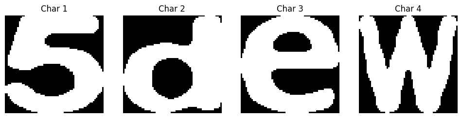

```
71hf: 4 resized characters
```

[figure not shown]

```
65o6: 4 resized characters
```

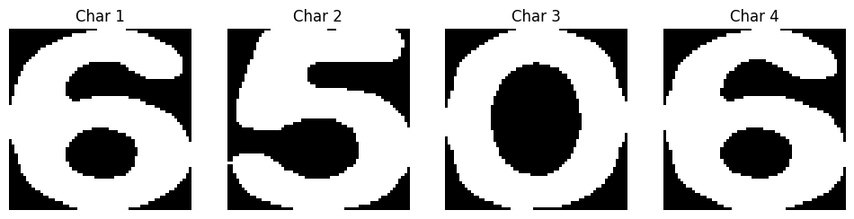

```python
# 2
resized_characters = []

target_size = (64, 64)

for img_name, chars in extracted_characters:

    resized_chars = []

    for char_img in chars:
        resized = cv.resize(char_img, target_size, interpolation=cv.INTER_NEAREST)
        resized_chars.append(resized)

    resized_characters.append((img_name, resized_chars))

#Report
random.seed(42)
selected = random.sample(resized_characters, 3)

for img_name, chars in selected:

    print(f"{img_name}: {len(chars)} resized characters")

    fig, axes = plt.subplots(1, len(chars), figsize=(3*len(chars), 3))

    if len(chars) == 1:
        axes = [axes]

    for i, char_img in enumerate(chars):
        axes[i].imshow(char_img, cmap="gray")
        axes[i].axis("off")
        axes[i].set_title(f"Char {i+1}")

    plt.show()
```

## PART 4 - Character Recognition

```python
# 1
map_folder_path = 'Mapset'
refs = {}

for filename in os.listdir(map_folder_path):
    label = os.path.splitext(filename)[0]

    img_path = os.path.join(map_folder_path, filename)
    ref_img = cv.imread(img_path, 0)
    refs[label] = ref_img

results = []

for img_name, chars in resized_characters:
    base = img_name.split(".")[0]
    for idx, char_img in enumerate(chars):

        best_score = -1.0
        best_match = None

        for lbl, ref_img in refs.items():
            score = ssim(char_img, ref_img)
            if score > best_score:
                best_score = score
                best_match = lbl

        results.append([f"{base}_{idx}.png", best_match, best_score])

with open("results.csv", "w", newline="", encoding="utf-8") as f:
    writer = csv.writer(f)
    writer.writerow(["segment file", "predicted label", "Metric"])
    writer.writerows(results)

print("Results saved to results.csv")
```

```
Results saved to results.csv
```

```python
# 2
wrong_pairs = []

correct_num = 0
for i in range(0, len(results)-length, length):
    correct_char = 0

    for j in range(length):

        pred = results[i+j][1]
        gt = results[i+j][0][j]

        if pred == gt:
            correct_char += 1

        else:
            # reference image from Mapset
            ref_name = results[i+j][1]
            ref_path = os.path.join("Mapset", ref_name)
            ref_img = cv.imread(ref_path, cv.IMREAD_GRAYSCALE)

            # original char image from resized_characters dict
            resized_characters_dict = dict(resized_characters)
            img_name = results[i+j][0].split("_")[0]
            orig_img = resized_characters_dict[img_name][j]

            wrong_pairs.append((orig_img, ref_img, gt, pred))

    if correct_char == length:
        correct_num += 1



if correct_char == length:
        correct_num += 1
print(correct_num)


# Report

print (f"final : {correct_num / number * 100} % ")
```

```
19
final : 95.0 %
```